# SLML_hw3

凌浩东

9/29/2021

# 1 合租模式下的租房价格分析

## 1.1 简介

本项目收集了北京市某年某月的5149条合租房源信息， 通过建模不同房源的内部结构和外部条件因子对房源月租金的影响， 得到了月租金与房源信息之间的**对数**线性模型。

统计结果表明， 在房源的各种信息因子中， 对月租金影响较大的因子包括卧室数， 卫生间数， 房间面积， 是否临近地铁， 所在城区， 以及供暖方式。 模型的均方根误差（RMSE）为0.152， 判定系数（R square）为0.67， 调整后的判定系数（Adjusted R-squared）为0.67。

下文将对统计和建模的过程进行具体描述。

## 1.2 数据读入与汇总统计

首先读入数据，根据csv文件的编码方式，选择`UTF-8`编码。

```r
data <- read.csv('data.csv', encoding = 'UTF-8')
head(data)
```

```
##   rent bedroom livingroom bathroom area room floor_grp subway region  heating
## 1 2730       2          1        1   12 主卧    高楼层     是   通州 集中供暖
## 2 2740       3          1        1    9 次卧    低楼层     是   昌平 集中供暖
## 3 2810       3          1        1   14 主卧    低楼层     是   丰台 集中供暖
## 4 2650       4          1        1    8 次卧    低楼层     是   丰台 集中供暖
## 5 2670       4          1        1   13 主卧    高楼层     否   丰台 集中供暖
## 6 2530       3          1        1   12 次卧    高楼层     是   顺义 集中供暖
```

展示数据前6行，可以看到一共有10列， 其中，第一列`rent`表示房间的月租金， 之后9列代表了房间的各种信息因子， 包括:

- 数字变量：房间数量（bedroom），客厅数（living room），卫生间数（bath room），房间面积（area）；
- 字符变量：房间类型（room），楼层（floor_grp），是否临近地铁（subway），所在城区（region），供暖方式（heating）。

使用`summary`方法，对数据进行初步的统计汇总如下。

```r
summary(data)
```

```
##       rent         bedroom        livingroom      bathroom          area
##  Min.   :1150   Min.   :2.000   Min.   :1.00   Min.   :1.000   Min.   : 5.00
##  1st Qu.:2240   1st Qu.:2.000   1st Qu.:1.00   1st Qu.:1.000   1st Qu.:10.00
##  Median :2690   Median :3.000   Median :1.00   Median :1.000   Median :12.00
##  Mean   :2798   Mean   :2.996   Mean   :1.01   Mean   :1.027   Mean   :12.85
##  3rd Qu.:3230   3rd Qu.:4.000   3rd Qu.:1.00   3rd Qu.:1.000   3rd Qu.:15.00
##  Max.   :6460   Max.   :5.000   Max.   :2.00   Max.   :2.000   Max.   :30.00
##
##    room       floor_grp    subway        region         heating
##  主卧:2289   中楼层:1878   否: 815   朝阳   :1317   自采暖  : 952
##  次卧:2860   低楼层:1679   是:4334   通州   : 819   集中供暖:4197
##              高楼层:1592             昌平   : 702
##                                      丰台   : 581
##                                      海淀   : 424
##                                      大兴   : 361
##                                      (Other): 945
```

## 1.3 绘制月租金直方图

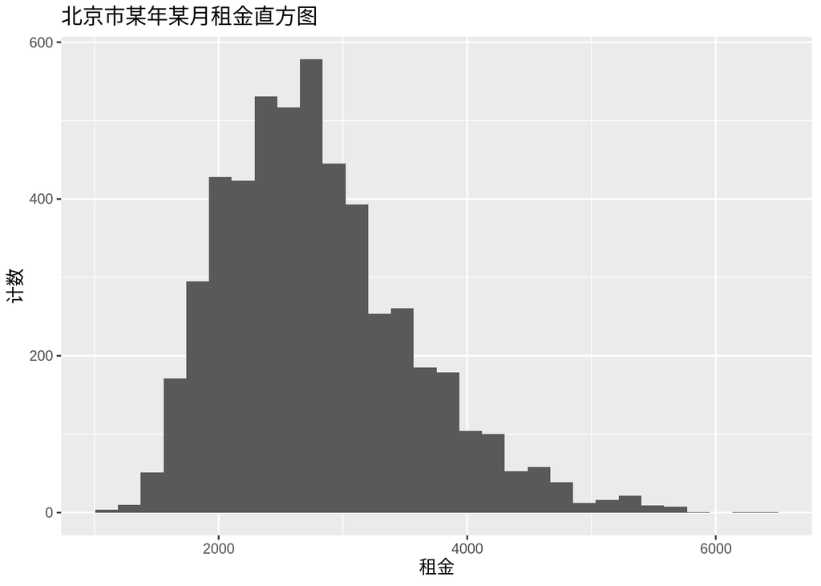

```r
library(ggplot2)
p <- ggplot(data = data,
            mapping = aes(x = rent)
            )
p + geom_histogram(bins=30) + labs(x = '租金', y = '计数', title = '北京市某年某月租金直方图')
```

通过直方图可以进一步验证之前得到的租金的大致分布情况， 租金呈右偏分布， 主要集中在2000到3000之间， 在2000以下的低价房和4000以上的高价房较少。

## 1.4 不同城区平均租金

计算不同城区租金平均值，按从大到小分布如下所示。

```r
rent_by_region <- aggregate(list(mean_rent = data$rent), list(region = data$region), FUN = mean)
rent_by_region <- rent_by_region[order(-rent_by_region$mean_rent),]
row.names(rent_by_region) <- NULL
rent_by_region
```

```
##    region mean_rent
## 1    西城  3784.792
## 2    海淀  3490.920
## 3    朝阳  3302.103
## 4    东城  3262.872
## 5  石景山  2819.845
## 6    丰台  2734.286
## 7    昌平  2693.376
## 8    通州  2327.216
## 9    大兴  2241.136
## 10   顺义  2111.497
## 11   房山  1751.257
```

可以看到，城区的平均租金按从大到小分布依次为西城，海淀，朝阳，东城，石景山，丰台，昌平，通州，大兴, 顺义。

取最高的八个，绘制条形图如下所示。

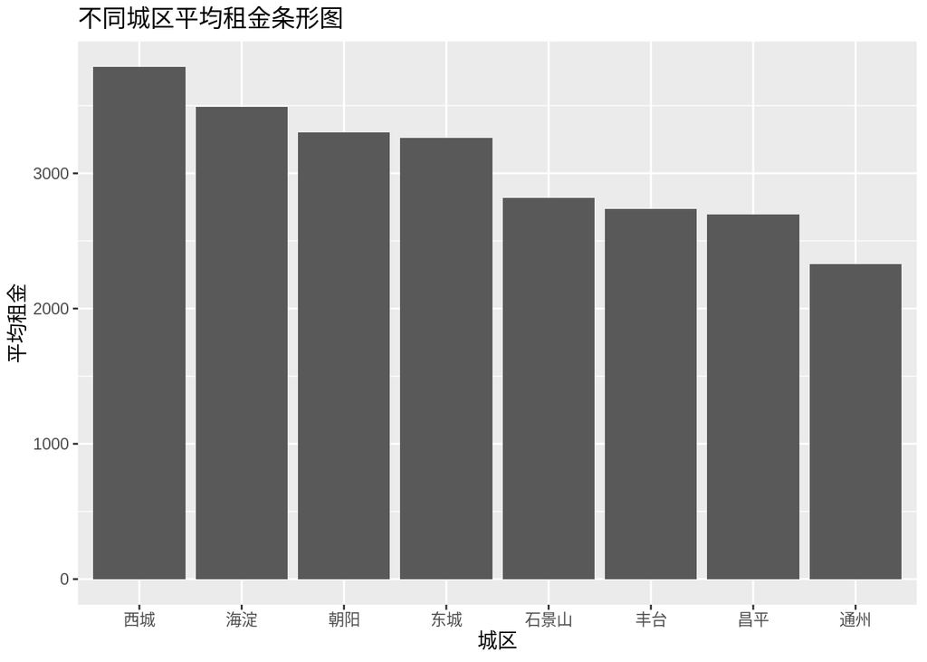

```r
rent_by_region <- rent_by_region[1:8,]
rent_by_region$region <- factor(rent_by_region$region, levels = rent_by_region$region)
ggplot(data = rent_by_region, aes(x=region, y = mean_rent)) +
  geom_bar(stat = 'identity') +
  labs(x = '城区', y = '平均租金', title = '不同城区平均租金条形图')
```

从条形图可见，西城，海淀，朝阳，东城的平均租金都超过了3000，其他城区的平均租金在3000以下。

## 1.5 月租金-城区箱线图

绘制月租金-城区箱线图入下所示。

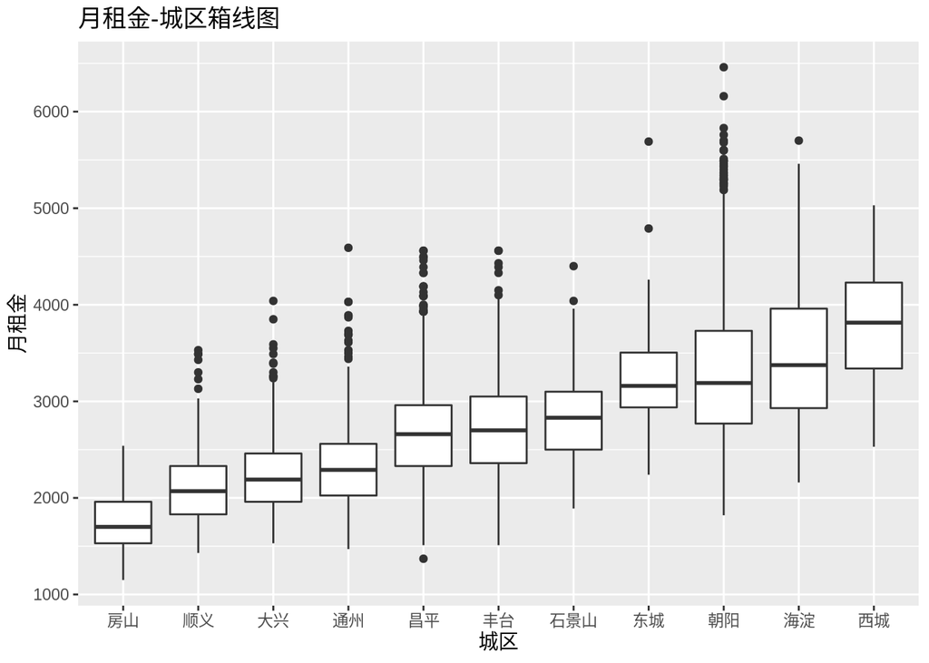

```r
ggplot(data, aes(x = reorder(region, rent, FUN = median), y = rent)) +
  geom_boxplot() +
  labs(x = '城区', y = '月租金', title = '月租金-城区箱线图')
```

对图像分析如下：

- 从中位数来看，依然是东城，朝阳，海淀，西城最高。
- 从分布离散程度来看，朝阳，海淀，西城分布得最离散， 大兴，房山，顺义得分布比较集中。
- 从异常点来看，昌平，朝阳，通州，高于正常范围的异常点较多。 只有昌平出现了低于正常范围的异常点。

## 1.6 线性回归

首先将按照要求将次卧，低楼层，远离地铁站，石景山，自采暖设置为哑变量。

```r
data$room <- factor(data$room, levels = c('次卧','主卧'))
data$floor_grp <- factor(data$floor_grp, levels = c('低楼层','中楼层','高楼层'))
data$subway <- factor(data$subway, c('否', '是'))
data$region <- factor(data$region, c('石景山','朝阳','海淀','东城','西城', '昌平','大兴', '通州', '丰台', '顺义', '房山'))
data$heating <- factor(data$heating, c('自采暖','集中供暖'))
```

然后，对数据进行线性回归拟合。

```r
model <- lm(rent~., data = data)
summary(model)
```

```
##
## Call:
## lm(formula = rent ~ ., data = data)
##
## Residuals:
##      Min       1Q   Median       3Q      Max
## -1617.48  -275.26   -23.21   248.40  2967.39
##
## Coefficients:
##                   Estimate Std. Error t value Pr(>|t|)
## (Intercept)     1593.22405   79.93979  19.930  < 2e-16 ***
## bedroom          -90.55187    8.73965 -10.361  < 2e-16 ***
## livingroom      -168.01859   71.84304  -2.339 0.019390 *
## bathroom         182.10825   43.63344   4.174 3.05e-05 ***
## area              76.69198    1.96317  39.065  < 2e-16 ***
## room主卧           0.08443   16.57165   0.005 0.995935
## floor_grp中楼层  -55.59610   15.29704  -3.634 0.000281 ***
## floor_grp高楼层  -24.98532   15.95019  -1.566 0.117303
## subway是         280.44440   17.73655  15.812  < 2e-16 ***
## region朝阳       631.69500   31.69727  19.929  < 2e-16 ***
## region海淀       878.86347   36.51087  24.071  < 2e-16 ***
## region东城       565.01670   55.05629  10.263  < 2e-16 ***
## region西城       938.86226   54.33181  17.280  < 2e-16 ***
## region昌平        57.19973   34.07111   1.679 0.093245 .
## region大兴      -421.98157   37.42529 -11.275  < 2e-16 ***
## region通州      -373.00568   32.65046 -11.424  < 2e-16 ***
## region丰台       117.59678   34.57808   3.401 0.000677 ***
## region顺义      -450.95937   39.11271 -11.530  < 2e-16 ***
## region房山      -811.82173   45.02264 -18.031  < 2e-16 ***
## heating集中供暖  155.79086   17.13452   9.092  < 2e-16 ***
## ---
## Signif. codes:  0 '***' 0.001 '**' 0.01 '*' 0.05 '.' 0.1 ' ' 1
##
## Residual standard error: 454.1 on 5129 degrees of freedom
## Multiple R-squared:  0.6466, Adjusted R-squared:  0.6453
## F-statistic: 493.9 on 19 and 5129 DF,  p-value: < 2.2e-16
```

从拟合结果可见，拟合的均方根误差为454.1，判定系数R方为0.65，调整后的R方为0.65。

## 1.7 使用BIC准则进行变量选择

使用`step`方法对模型变量进行选择。

值得注意的是`step`方法中， 变量k的默认值为2，表示的是**AIC**(Akaike Information Criterion), 将k设置为$\log\left(n\right)$， 其中n表示数据点的个数， 就能使用**BIC**(Bayesian Information Criterion)。

```r
selected_model <- step(model, k = log(5149))
```

```r
summary(selected_model)
```

```
##
## Call:
## lm(formula = rent ~ bedroom + bathroom + area + subway + region +
##     heating, data = data)
##
## Residuals:
##      Min       1Q   Median       3Q      Max
## -1611.79  -271.91   -25.92   248.37  2980.50
##
## Coefficients:
##                 Estimate Std. Error t value Pr(>|t|)
## (Intercept)     1440.449     59.027  24.403  < 2e-16 ***
## bedroom          -91.457      8.547 -10.701  < 2e-16 ***
## bathroom         141.751     40.550   3.496 0.000477 ***
## area              76.527      1.533  49.930  < 2e-16 ***
## subway是         281.206     17.743  15.849  < 2e-16 ***
## region朝阳       634.860     31.729  20.009  < 2e-16 ***
## region海淀       880.960     36.546  24.106  < 2e-16 ***
## region东城       565.767     55.124  10.264  < 2e-16 ***
## region西城       935.072     54.387  17.193  < 2e-16 ***
## region昌平        58.700     34.104   1.721 0.085276 .
## region大兴      -418.866     37.422 -11.193  < 2e-16 ***
## region通州      -372.159     32.685 -11.386  < 2e-16 ***
## region丰台       119.461     34.606   3.452 0.000561 ***
## region顺义      -456.412     39.038 -11.691  < 2e-16 ***
## region房山      -808.478     45.011 -17.962  < 2e-16 ***
## heating集中供暖  154.970     17.150   9.036  < 2e-16 ***
## ---
## Signif. codes:  0 '***' 0.001 '**' 0.01 '*' 0.05 '.' 0.1 ' ' 1
##
## Residual standard error: 454.7 on 5133 degrees of freedom
## Multiple R-squared:  0.6453, Adjusted R-squared:  0.6443
## F-statistic: 622.7 on 15 and 5133 DF,  p-value: < 2.2e-16
```

变量选择后，得到拟合结果中， 均方根误差为454.7，R方为0.65，调整后的R方为0.64。

## 1.8 交叉验证

```r
library(DAAG)
cvlm <- cv.lm(data, selected_model, m = 5, printit = F, seed = 42)
```

```r
attr(cvlm, 'ms')
```

```
## [1] 207581
```

五折交叉验证结果显示，模型的误差较大，说明线性回归模型的效果不佳。

对模型进行回归诊断：

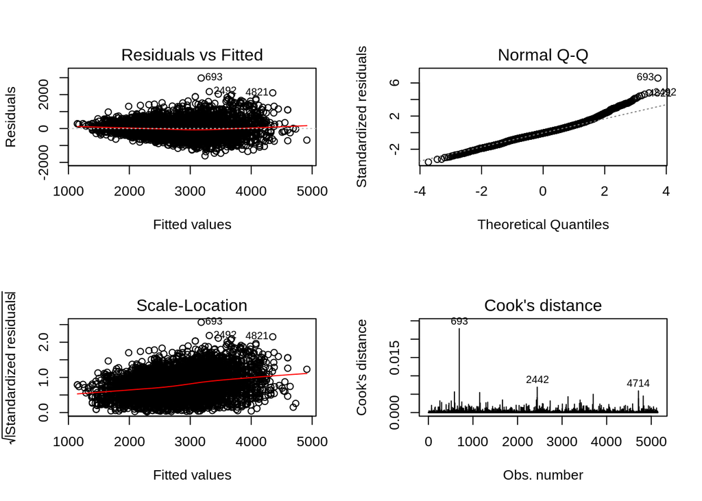

```r
par(mfrow=c(2,2))
plot(selected_model, which=c(1:4))
```

下面，尝试对数线性模型。

```r
loglm <- lm(log(rent)~., data)
summary(loglm)
```

```
##
## Call:
## lm(formula = log(rent) ~ ., data = data)
##
## Residuals:
##      Min       1Q   Median       3Q      Max
## -0.66036 -0.09473  0.00008  0.09992  0.69552
##
## Coefficients:
##                  Estimate Std. Error t value Pr(>|t|)
## (Intercept)      7.526630   0.026713 281.755  < 2e-16 ***
## bedroom         -0.036754   0.002920 -12.585  < 2e-16 ***
## livingroom      -0.044047   0.024008  -1.835  0.06661 .
## bathroom         0.064026   0.014581   4.391 1.15e-05 ***
## area             0.025198   0.000656  38.410  < 2e-16 ***
## room主卧         0.004432   0.005538   0.800  0.42355
## floor_grp中楼层 -0.020409   0.005112  -3.992 6.63e-05 ***
## floor_grp高楼层 -0.010528   0.005330  -1.975  0.04829 *
## subway是         0.105890   0.005927  17.866  < 2e-16 ***
## region朝阳       0.197869   0.010592  18.681  < 2e-16 ***
## region海淀       0.274740   0.012201  22.518  < 2e-16 ***
## region东城       0.188609   0.018398  10.252  < 2e-16 ***
## region西城       0.285027   0.018156  15.699  < 2e-16 ***
## region昌平       0.010431   0.011385   0.916  0.35961
## region大兴      -0.178279   0.012506 -14.255  < 2e-16 ***
## region通州      -0.153112   0.010911 -14.033  < 2e-16 ***
## region丰台       0.032436   0.011555   2.807  0.00502 **
## region顺义      -0.201067   0.013070 -15.384  < 2e-16 ***
## region房山      -0.395786   0.015045 -26.307  < 2e-16 ***
## heating集中供暖  0.042917   0.005726   7.495 7.75e-14 ***
## ---
## Signif. codes:  0 '***' 0.001 '**' 0.01 '*' 0.05 '.' 0.1 ' ' 1
##
## Residual standard error: 0.1517 on 5129 degrees of freedom
## Multiple R-squared:  0.6759, Adjusted R-squared:  0.6747
## F-statistic:   563 on 19 and 5129 DF,  p-value: < 2.2e-16
```

```r
selected_loglm <- step(loglm, k = log(5149))
```

```r
summary(selected_loglm)
```

```
##
## Call:
## lm(formula = log(rent) ~ bedroom + bathroom + area + subway +
##     region + heating, data = data)
##
## Residuals:
##      Min       1Q   Median       3Q      Max
## -0.65849 -0.09480 -0.00018  0.09992  0.69651
##
## Coefficients:
##                   Estimate Std. Error t value Pr(>|t|)
## (Intercept)      7.4828542  0.0197277 379.307  < 2e-16 ***
## bedroom         -0.0373880  0.0028564 -13.089  < 2e-16 ***
## bathroom         0.0527619  0.0135526   3.893  0.00010 ***
## area             0.0254751  0.0005123  49.732  < 2e-16 ***
## subway是         0.1059632  0.0059298  17.869  < 2e-16 ***
## region朝阳       0.1990899  0.0106043  18.774  < 2e-16 ***
## region海淀       0.2755829  0.0122142  22.563  < 2e-16 ***
## region东城       0.1891943  0.0184233  10.269  < 2e-16 ***
## region西城       0.2834162  0.0181772  15.592  < 2e-16 ***
## region昌平       0.0106945  0.0113982   0.938  0.34815
## region大兴      -0.1767436  0.0125070 -14.132  < 2e-16 ***
## region通州      -0.1526145  0.0109240 -13.971  < 2e-16 ***
## region丰台       0.0332367  0.0115660   2.874  0.00407 **
## region顺义      -0.2020836  0.0130473 -15.489  < 2e-16 ***
## region房山      -0.3940076  0.0150433 -26.192  < 2e-16 ***
## heating集中供暖  0.0426056  0.0057316   7.433 1.23e-13 ***
## ---
## Signif. codes:  0 '***' 0.001 '**' 0.01 '*' 0.05 '.' 0.1 ' ' 1
##
## Residual standard error: 0.152 on 5133 degrees of freedom
## Multiple R-squared:  0.6747, Adjusted R-squared:  0.6737
## F-statistic: 709.6 on 15 and 5133 DF,  p-value: < 2.2e-16
```

```r
cvloglm <- cv.lm(data, selected_loglm, m = 5, printit = F, seed = 42)
```

```r
attr(cvloglm, 'ms')
```

```
## [1] 0.0231759
```

误差小了许多。

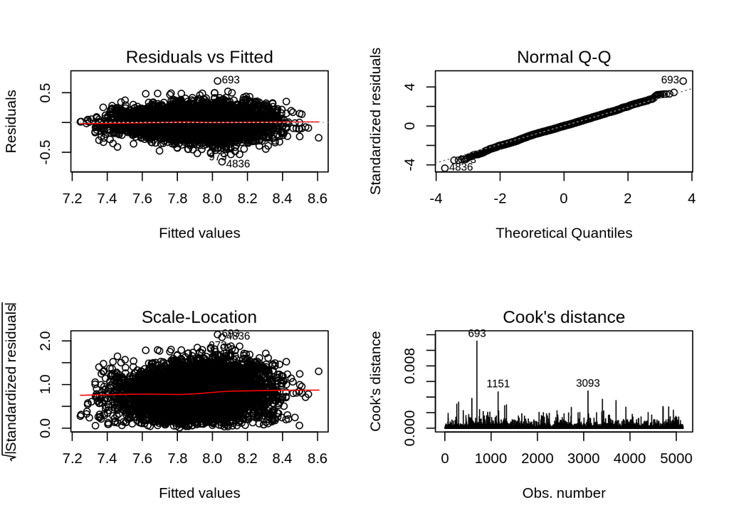

```r
par(mfrow=c(2,2))
plot(selected_loglm, which=c(1:4))
```

通过回归诊断可见，异方差情况好了很多。

## 1.9 总结

本文对北京某年某月的5149条合租房源信息， 通过建模不同房源的内部结构和外部条件因子对房源月租金的影响， 得到了月租金与房源信息之间的模型。

在统计过程中， 通过五折交叉验证以及回归诊断， 发现线性模型的不适用， 最终采用了对数线性模型， 较好地拟合了数据。

统计结果表明， 卫生间数，面积，临近地铁，集中供暖对租金起正向作用， 房间数对租金起负向作用。 模型的均方根误差（RMSE）为0.152， 判定系数（R square）为0.67， 调整后的判定系数（Adjusted R-squared）为0.67。